# Data Analysis Project 1

## Experiment2: PCA with scaling + LDA

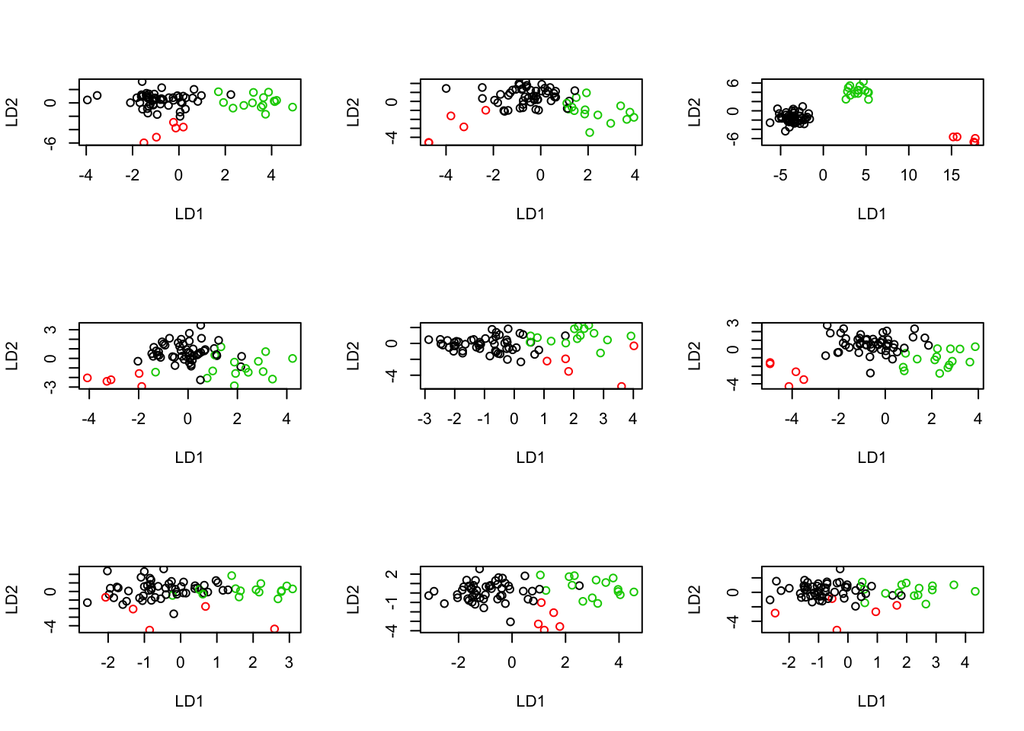

```r
# First, need to remove columns for the tokens that vary (probably don't appear in y)
absent <- which(apply(y, 2, var)==0)
z <- y[, -absent]

# we then do LDA
library(MASS)

#choose 40 pincipal components to start with
w <- as.matrix(y) %*% p$rotation[, 1:40]
l <- lda(w, grouping=b)

#make a null lineup to compare observed separation of the documents with null results
par(mfrow = c(3, 3))
answer <- sample(1:9, 1)
for (i in 1:9) {
  if (i == answer) {
    # LDA for the original data
    plot(as.matrix(w) %*% l$scaling[, 1:2], col=b)
  } else {
    # LDA with labels reassigned at random
    B <- sample(b, length(b))
    L <- lda(w, grouping=B)
    plot(as.matrix(w) %*% L$scaling[, 1:2], col=B)
  }
}
```

## From the 9 plots we can clearly see that there is a true plot, which shows clear clusters of points.

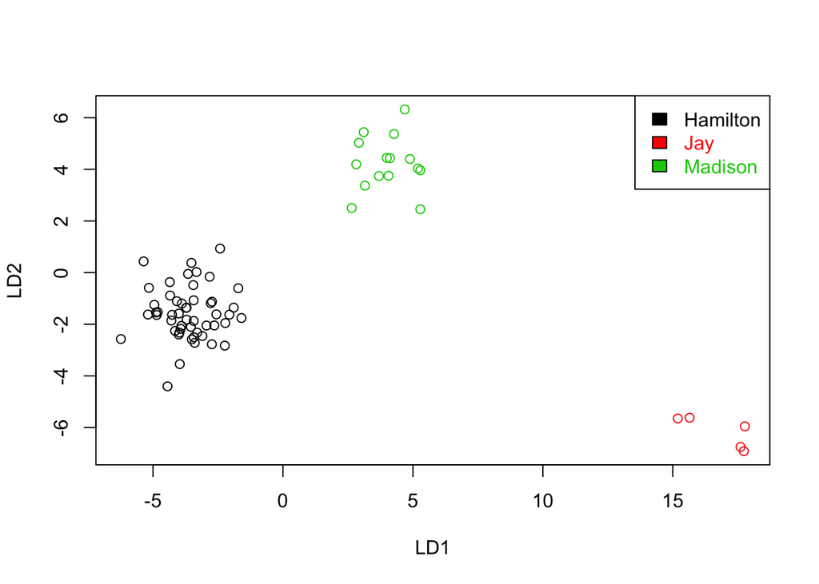

```r
#look at the true plot
plot(as.matrix(w) %*% l$scaling[, 1:2], col=b)
legend("topright", levels(b), text.col=1:length(b),
       fill=1:length(levels(b)))
```

## From the plot we can see that after performing PCA then LDA, the patterns are more clear. There seem to be separate clusters of documents written by different authors.

# Experiment3: Change the number of principal components

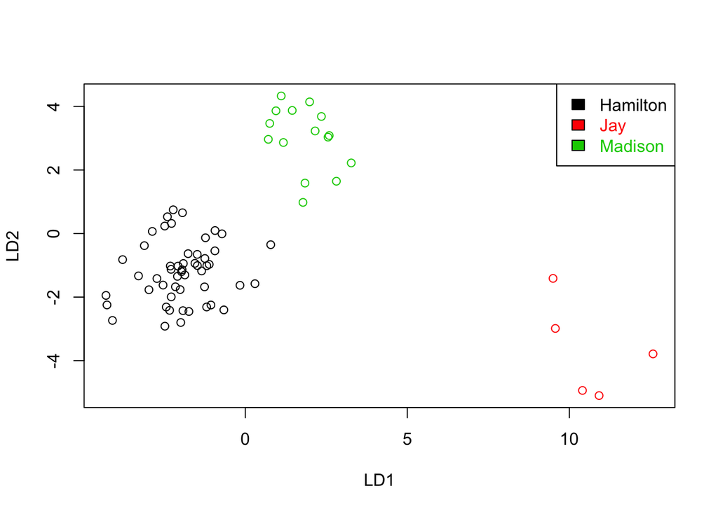

```r
#try 20 principal components
w_1 <- as.matrix(y) %*% p$rotation[, 1:20]
#so that it captures 20/71 of the variance of the data

#LDA
l <- lda(w_1, grouping=b)

#look at the plot
plot(as.matrix(w_1) %*% l$scaling[, 1:2], col=b)
legend("topright", levels(b), text.col=1:length(b),
       fill=1:length(levels(b)))
```

## We can see that as we reduce the number of principal components, the points become less clustered. Fewer number of PCs means that we are capturing less variance of the data. This allows the points to have more freedom to be spread out. As a result, we see that the clusters of points are not so centralized compared to when we use 40 PCs.

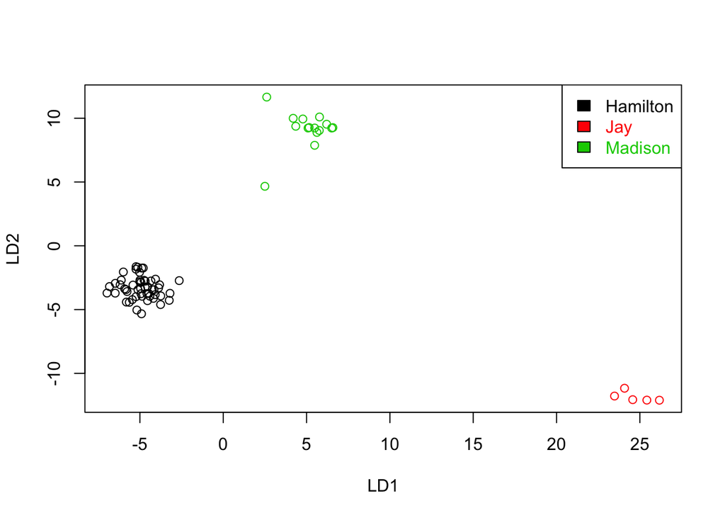

```r
#try 60 principal components
w_2 <- as.matrix(y) %*% p$rotation[, 1:60]
#so that it captures 60/71 of the variance of the data

l <- lda(w_2, grouping=b)

#look at the plot
par(mfrow = c(1, 1))

plot(as.matrix(w_2) %*% l$scaling[, 1:2], col=b)
legend("topright", levels(b), text.col=1:length(b),
       fill=1:length(levels(b)))
```

## We can see that as we increase the number of principal components, the points become more clustered. Greater number of PCs means that we are capturing more variance of the data. This allows the points to have less freedom to be spread out. As a result, we see that the clusters of points are more centralized compared to when we use 40 PCs.

## Experiment4: remove stopwords

## We want to remove stopwords because some words generally tend to have high frequency in any writing and might not be related to author’s specific writing style.

```r
#read in the frequency table after removing stopwords "and", "the", "a", "an"

x_new <- read.csv("/Users/graceyin/Desktop/data analysis/Project1/frequency table new.csv", row.names=1)
x_new[1:6, 1:6]
```

```
##   commotion surreptitious sketch      analogy proportioned substance
## 0         0             0      0 0.0006389776            0         0
## 1         0             0      0 0.0000000000            0         0
## 2         0             0      0 0.0000000000            0         0
## 3         0             0      0 0.0000000000            0         0
## 4         0             0      0 0.0000000000            0         0
## 5         0             0      0 0.0000000000            0         0
```

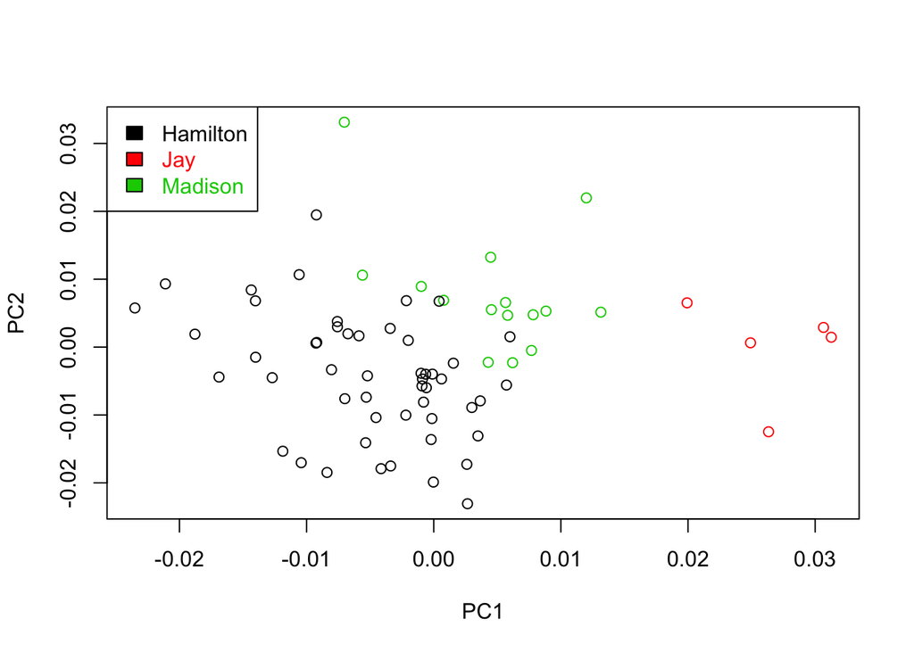

```r
xbar <- apply(x_new, 2, mean)
for(i in 1:nrow(x_new)) {
  x_new[i, ] <- x_new[i, ] - xbar
}

#identify the author of each document
single <- a %in% c("Hamilton", "Madison", "Jay")
y_new <- x_new[single, ]
b_new <- as.factor(as.character(a[single]))

#PCA without scaling
p_new <- prcomp(y_new)

plot(as.matrix(y_new) %*% p_new$rotation[, 1:2], col=b_new)
legend("topleft", levels(b_new), text.col=1:length(levels(b_new)),
       fill=1:length(levels(b_new)))
```

## From the plot we can see that the points become more scattered and show less clear patterns of authorship. This might indicate that it is not a good idea to remove stopwords in the documents because it may disrupt the true pattern of authors’ writing styles. For the purpose of preserving completeness of the data, we use frequency table without removing stopwords for later analysis.

# Part VI: Perform 100 cross-validation trials with y, each time training your classi cation procedure (presumably PCA then LDA) on 66 of the points, then seeing how well the classification performs on 5 test points.

## Approach 1: Use PCA then LDA to find the classification error rate on 5 test points

```r
set.seed(2048)
#create lists to store confusion matrix and classification errors for the trainning and testing datasets
train.tables <- vector(mode = "list", length = 100)
train.errorlist <- vector(mode = "list", length = 100)

test.tables <- vector(mode = "list", length = 100)
test.errorlist <- vector(mode = "list", length = 100)

#perform 100 cross validations
for (i in 1:100){

  leave <- sample(1:nrow(y), 5)
  train <- y[-leave, ]
  b.train <- b[-leave]
  p <- prcomp(train)
  l <- lda(as.matrix(train) %*% p$rotation[, 1:40], grouping=b.train)

  # train prediction
  pred.train <- predict(l, as.matrix(y[-leave, ]) %*%  p$rotation[,1:40])$class
  tbl.train<- table(pred.train, b[-leave])

  # test prediction
  pred.test <- predict(l, as.matrix(y[leave, ]) %*% p$rotation[, 1:40])$class
  tbl.test<- table(pred.test, b[leave])

  # training error rate
  error.train<-1-(sum(diag(tbl.train)/sum(tbl.train)))
  train.tables[[i]] <- tbl.train
  train.errorlist[i]<-error.train

  # testing error rate
  error.test<-1-(sum(diag(tbl.test)/sum(tbl.test)))
  test.tables[[i]] <- tbl.test
  test.errorlist[i]<-error.test
}

# look at the first 5 confusion matrix
test.tables[0:5]
```

```
## [[1]]
##
## pred.test  Hamilton Jay Madison
##   Hamilton        5   0       0
##   Jay             0   0       0
##   Madison         0   0       0
##
## [[2]]
##
## pred.test  Hamilton Jay Madison
##   Hamilton        3   0       0
##   Jay             0   0       0
##   Madison         0   0       2
##
## [[3]]
##
## pred.test  Hamilton Jay Madison
##   Hamilton        4   0       0
##   Jay             0   0       0
##   Madison         0   0       1
##
## [[4]]
##
## pred.test  Hamilton Jay Madison
##   Hamilton        4   0       0
##   Jay             0   0       0
##   Madison         0   0       1
##
## [[5]]
##
## pred.test  Hamilton Jay Madison
##   Hamilton        4   0       0
##   Jay             0   0       0
##   Madison         0   0       1
```

```r
# look at the first 5 classification error rate
test.errorlist[0:5]
```

```
## [[1]]
## [1] 0
##
## [[2]]
## [1] 0
##
## [[3]]
## [1] 0
##
## [[4]]
## [1] 0
##
## [[5]]
## [1] 0
```